# Data 101 Project - Exploratory Data Analysis

Kate Berman

10/31/2018

### Begin Project 2:

Load packages and read in the data file

```r
library(dplyr)
library(tidyverse)
library(ggplot2)
  profsal<- read_csv("Salaries.csv")
```

The gender paygap in the U.S. is the ratio of female to male average yearly earnings among full-time year around workers.

The average woman’s unadjusted annual salary is 80% of that of the average man’s, according to Fontenot, K., Semega, J., & Kollar, M. (2018). Income and Poverty in the United States: 2017. Washington: U.S. Census Bureau.

My question: Do the female professors in this “Salaries.csv” dataset who have the same qualifications and years of experience as the male professors trend with the rest of the U.S. population in getting paid 80% of what their male counterparts make for the same job?

Or will we be pleasantly surprised?

But before we answer this question, let’s re-run some code from Project 1 Data Cleaning. This Project 1 cleaned “Salaries.csv”(profsal) and made the data tidy.

```r
profsal.tenured<- mutate(profsal, tenured = rank != "AsstProf")
profsal.phd.service.gap<- mutate(profsal, gap = yrs.since.phd - yrs.service)
profsal.no.neg.nums<- filter(profsal.phd.service.gap, gap > 0)
profsal.tidy<-  merge(profsal.tenured, profsal.phd.service.gap, all = TRUE)
profsal.tidy.final<- filter(profsal.tidy, gap > 0)
```

Now that our data is tidy, let’s graph it.

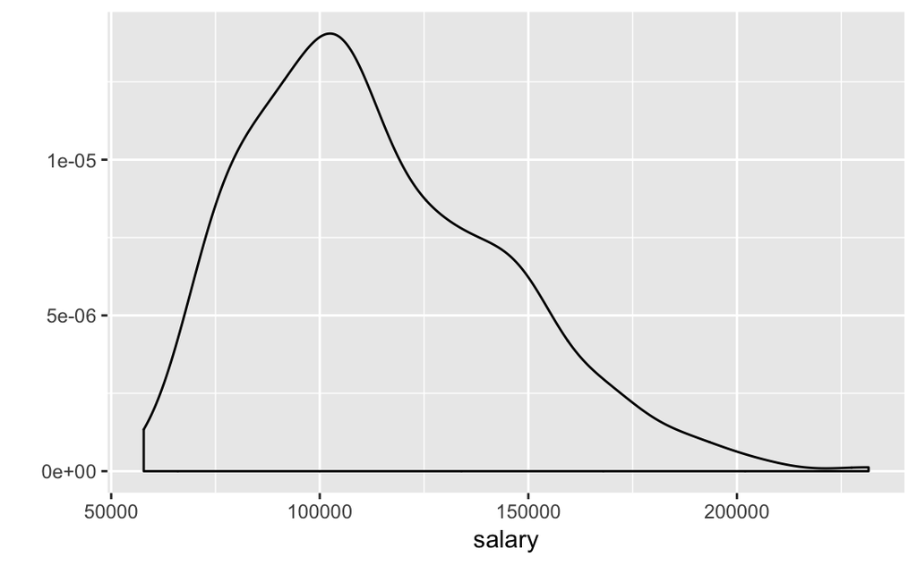

```r
qplot(salary, data=profsal, geom="density")
```

How different would this density be if we look at males and females seperately?

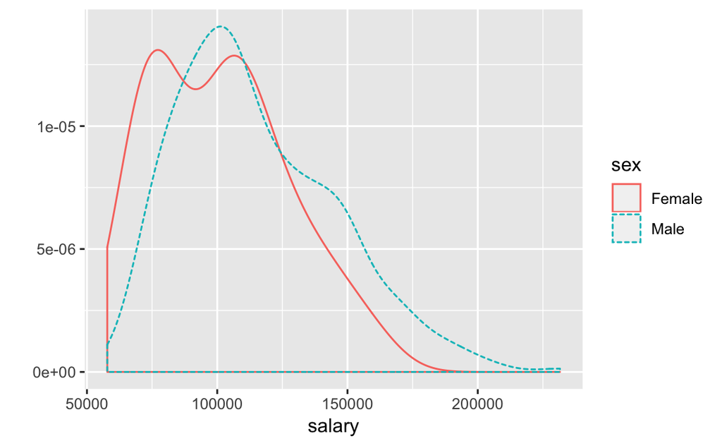

```r
qplot(salary, data=profsal, geom="density", color=sex, linetype=sex)
```

The line for Male professors looks almost exactly the same as the density line for all professors. But the density line for female professors is very different!

With the female density line so different, how can the male density line not be affected when the two lines are combined? My guess is that there are many more male professors than female professors in this dataset, so the data for female professors does not significantly affect the overall data.

Let’s see if that is in fact the case. Next I separate male and female and see.

```r
profsal.female<- filter(profsal, sex == "Female")
str(profsal.female,1)
```

```
Classes ‘tbl_df’, ‘tbl’ and 'data.frame':   39 obs. of  7 variables:
 $ X1           : int  10 20 25 35 36 48 49 53 64 69 ...
 $ rank         : chr  "Prof" "Prof" "AssocProf" "AsstProf" ...
 $ discipline   : chr  "B" "A" "A" "B" ...
 $ yrs.since.phd: int  18 39 13 4 5 23 25 11 11 17 ...
 $ yrs.service  : int  18 36 8 2 0 19 25 3 11 17 ...
 $ sex          : chr  "Female" "Female" "Female" "Female" ...
 $ salary       : int  129000 137000 74830 80225 77000 151768 140096 74692 103613 111512 ...
 - attr(*, "spec")=List of 2
  ..- attr(*, "class")= chr "col_spec"
```

```r
profsal.male<- filter(profsal, sex == "Male")
str(profsal.male,1)
```

```
Classes ‘tbl_df’, ‘tbl’ and 'data.frame':   358 obs. of  7 variables:
 $ X1           : int  1 2 3 4 5 6 7 8 9 11 ...
 $ rank         : chr  "Prof" "Prof" "AsstProf" "Prof" ...
 $ discipline   : chr  "B" "B" "B" "B" ...
 $ yrs.since.phd: int  19 20 4 45 40 6 30 45 21 12 ...
 $ yrs.service  : int  18 16 3 39 41 6 23 45 20 8 ...
 $ sex          : chr  "Male" "Male" "Male" "Male" ...
 $ salary       : int  139750 173200 79750 115000 141500 97000 175000 147765 119250 119800 ...
 - attr(*, "spec")=List of 2
  ..- attr(*, "class")= chr "col_spec"
```

Now we see that of the 397 total, there are 39 female professors to 358 male professors. In other words, female professors make up roughly 10% of the of the data. Clearly not enough to have much influence on this density graph.

Interestingly, the female professor’s line is bimodal. There’s a dip in the top of the female professors line that begins at about $75,000 and continues to about $85,000 before it goes up again. Meanwhile, the line for male professors continues to scale higher to a peak of $100,000. Then, the lines converge from about $115,000 to about $125,000. After that, the male professors make more money proportionately than their female counterparts through to the top pay of $231,545.

What would we learn if we separated this density plot as to rank?

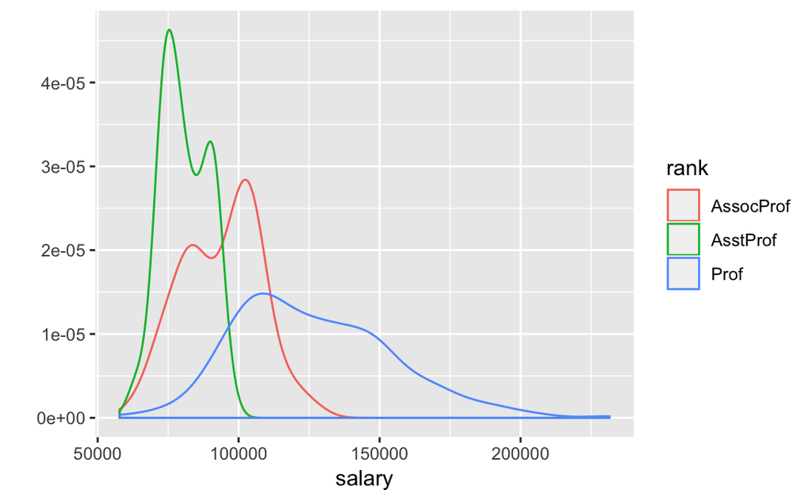

```r
qplot(salary, data=profsal, geom="density", color=rank)
```

We see nothing too surprising here. The lowest pay goes to the Assistant Professors, Assistant Professors overlap a bit with the Associate Professors, with about half of the Associate Professors making more than the Associate Professors. The full Professors overlap with both the Associate and Assistant Professors, but make by far the most overall.

Now let’s split it up and look at the density plot of just females, with a line for each rank.

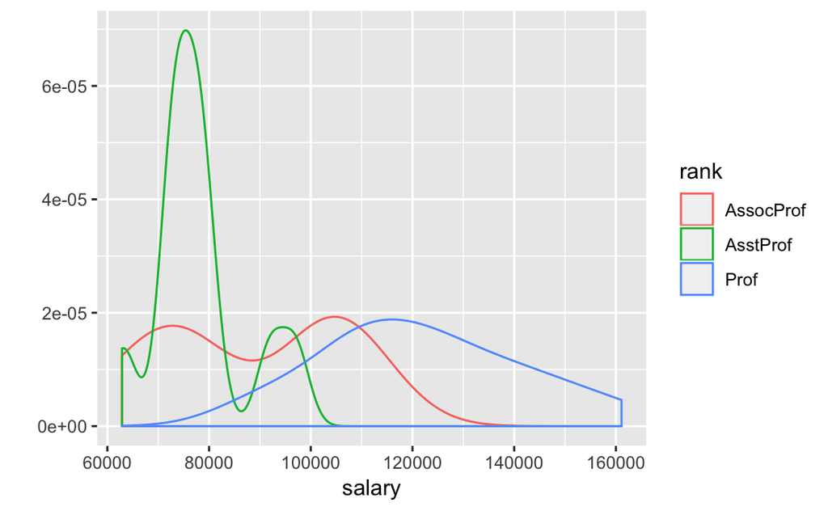

```r
qplot(salary, data=profsal.female, geom="density", color=rank)
```

This plot looks very different! There’s a lot going on here, but notice that the x axis ends at $160,000. The x axis on the density graph for all professors went to roughly $230,000. So, where the highest salaries are, on the right tail of the graph, there are no salaries for female professors. Roughly a third of this x axis is missing compared to the graph for all Professors. The top third of all salaries go to Male professors.

Let’s look at the male Professor’s density graph.

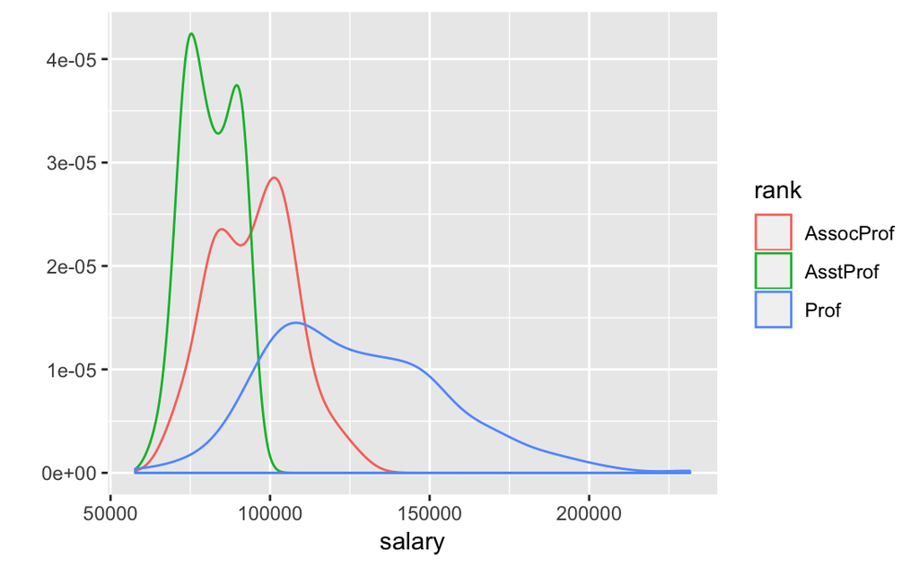

```r
qplot(salary, data=profsal.male, geom="density", color=rank)
```

Not surprisingly, this graph looks almost exactly like the salary density graph for all the professors. Again, because there are proportionately so few female professors in this dataset, the males will trend with the overall picture.

So far we’ve only looked at salary as it relates to rank and sex. An important factor as to how much a person is paid at any given job is education and years of service.

In this dataset, all the professors may not have the same education, but all do have a Phd. And there are differences as to how many years passed between recieving their Phd.s and starting work at the College. Plus, there is one more variable - gap, which is the years between recieving a Phd and beginning to work at the University.

Let’s break this down. First, we’ll look at years of service.

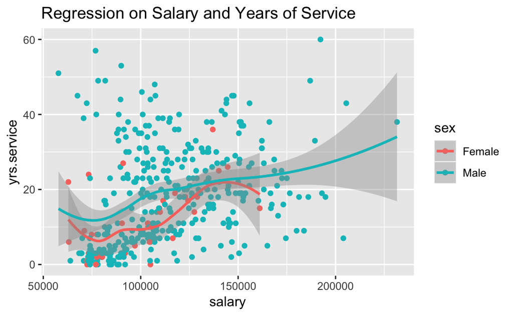

```r
qplot(salary, yrs.service, data=profsal, color=sex, geom=c("point","smooth"),main="Regression on Salary and Years of Service")
```

As you can see, Male Professors in general have a bit more years of service overall. We may want to break this down into rank at another time. Since this is a messy, hard to read graph, let’s look at the data for years of service another way.

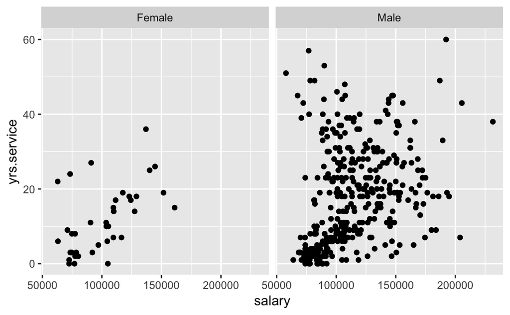

```r
qplot(salary, yrs.service, data=profsal, facets=.~sex)
```

It appears, from looking at the top of the above scatterplot, that Male Professors overall have more years of service. But there’s something interesting here. Take a look at the lower right quadrant of both graphs, at roughly 40 years of service and less, and $150,000 salary and more. That part of the graph for female professors is empty except for two points. Comparatively, that part of the Male Professor’s graph is quite full with roughly 50 datapoints. These 48 Male Professors are being paid more for the same years of expereince as their Female couterparts. But is that statistically significant? That might be something to look into with Project 3.

Now let’s move on to the variable gap. Gap is the time between getting a Phd and the start of service.

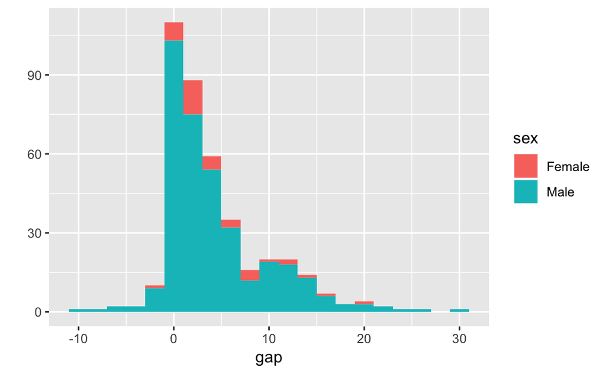

```r
qplot(gap, data=profsal.phd.service.gap, fill=sex, binwidth=2)
```

The Female Professors seem to have a gap betwen their Phd and service a bit more frequently at most gap years, but the binline follows the shape of the Male Professor’s gap pretty closely with most Professors having a gap of about 8 years or less. There doesn’t appear to be any significant difference in gap.

The last variable we’ll look at is “discipline”. We don’t know an awful lot about this variable. What we do know is that Professors who work in A are working in Theorectical Departments, and Professors who work in B are working in Applied Departments. Is there any difference in salary between the two departments?

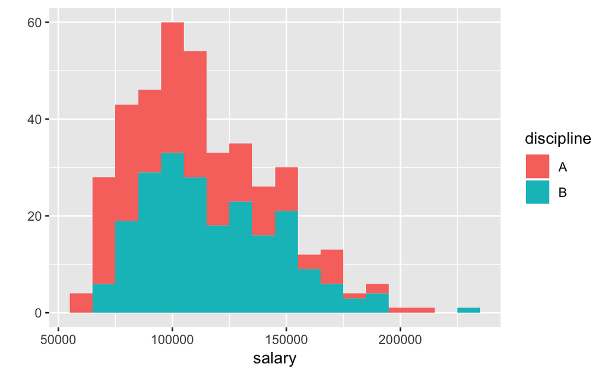

```r
qplot(salary, data=profsal, fill=discipline, binwidth=10000)
```

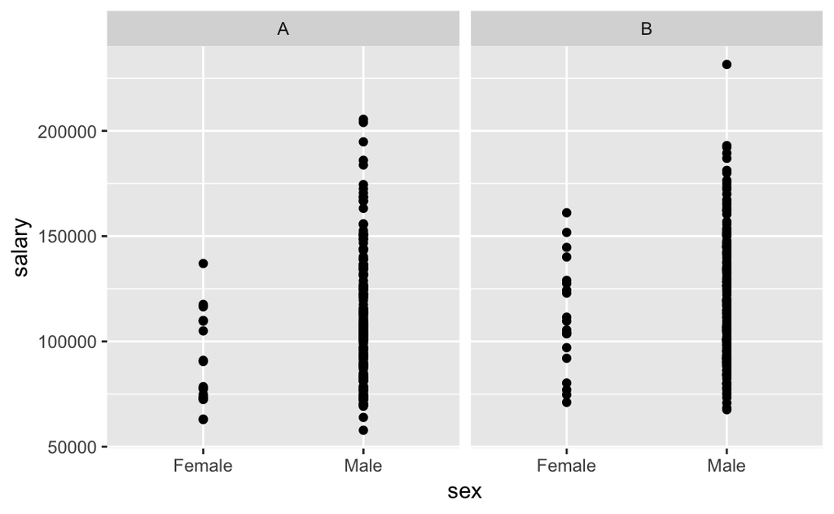

```r
qplot(sex, salary, data=profsal, facets=.~discipline)
```

With this plot it looks like B might be paid better than A. So which is it? Let’s try a box and whiskers plot for a more accurate answer.

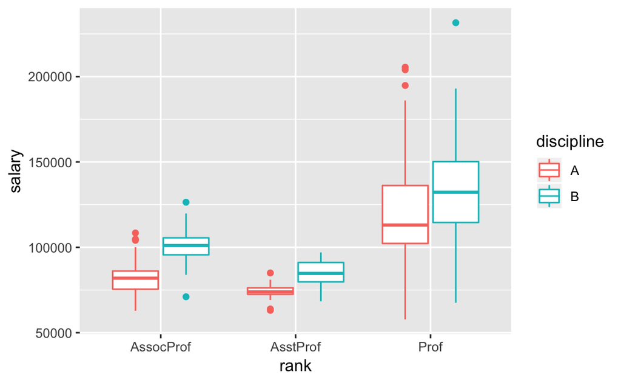

```r
qplot(rank,salary, data=profsal, geom="boxplot",color=discipline)
```

Voilà! This box and whisker plot shows the interquartile range for each rank by discipline. And in each rank, professors in discipline B make more money. Are there proportionally an even number of Male and Female Professors in each discipline, A and B?

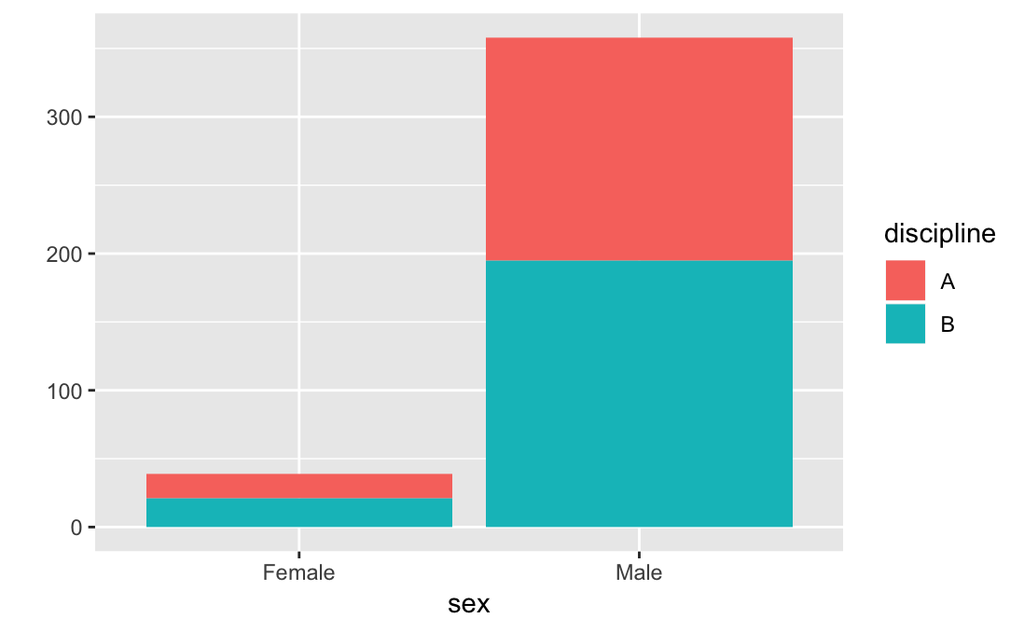

```r
qplot(sex, data=profsal, fill=discipline)
```

Using a box and whisker plot was a very clear way to visualize differences in pay. So, let’s apply it to the question at hand which was do the female professors in this “Salaries.csv” dataset who have the same qualifications and years of experience as the male professors trend with the rest of the U.S. population in getting paid 80% of what their male counterparts make for the same job?

We have seen that it looks like the Male Professors have a bit more years of service than the Female Professors in this dataset. So, taking that into consideration, let’s look at a box and whisker plot that shows Male and Female salaries by rank.

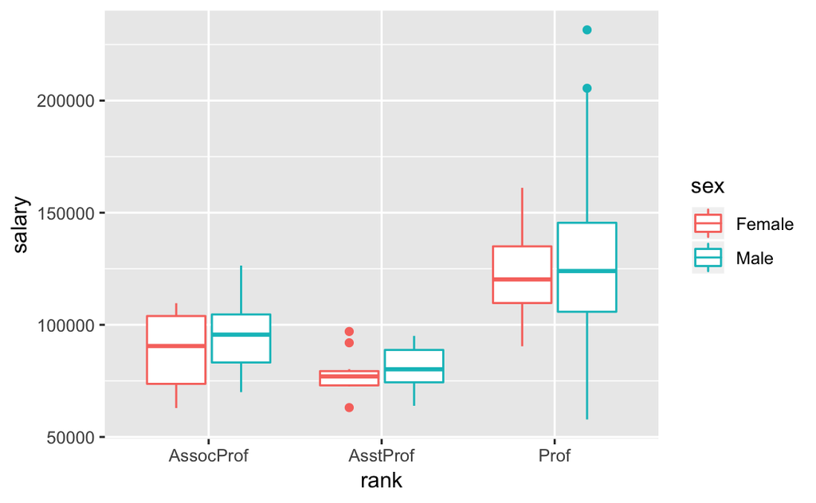

```r
qplot(rank,salary,data=profsal, geom="boxplot",color=sex)
```

Starting with the lowest rank, Assistant Professors, we see that the entire interquartile range for the Female professors fits almost entirely into the lower half of Male Professor’s range. Meaning, the Female Assistant Professors make at most the Male Assistant Professor’s median income, except for two outliers. This is significant because future pay is based on past pay, and if a person starts out being paid less than others of the same rank, that pay disparity can follow them into the higher ranks. Let’s see if that happens here.

Looking at the next highest rank, Associate Professors, we see the third quartile of the interquartile range for both the Male and Female Professors are the same. However, the median as well as the whiskers on the Associate Male Professor’s box stretch higher than the Female’s. Furthermore, the Associate Female Professor’s box extends into a lower salary range, showing about a $10,000 difference in pay

Lastly, we have full Professors. The median for Female Professors like the other two ranks is lower than the Male Professor’s median. Furthermore, the third quartile shows about a $12,000 advantage for Male Professors. But, the lower end, the first quartile for Female Professors, is a bit higher than the Male Professor’s. Additionally, the Male Professor’s boxplot has very long whiskers that extend from about $6,0000 to a bit more than $200,000. This lower reading for Male Professor’s salary makes me believe that while all Professors of all ranks work through the school year, some full Professors work part-time.

Furthermore, there is quite a long whisker on the top end of salary for full Male Professors. What could this be due to? My guess would be that there are a handful of men who are considered stars, either due to their years of experience or the mastery of their subject, or both. Interestingly, not one is a woman.

Finally, disregarding years of service, are Male and Female Professors of all ranks paid equally?

```r
mean.profsal.female<-mean(profsal.female$salary)
mean.profsal.male<-mean(profsal.male$salary)
pay.gap<-mean.profsal.female/mean.profsal.male
print(pay.gap)
```

```
[1] 0.8775918
```

In the above code, I took the mean Female Professor’s salary and divided it by the mean Male Professor’s salary. If pay were equal, the result would have been 1, meaning that proportionally, Male Professors and Female Professors salaries are the same. But we see here that that is not the case. Our result is 0.8775918, which means the Female Professor’s salary is a portion of the Male Professor’s salary - around 88%, which is better than the national average of 80%, but a significant difference of 12% persists.

Could this gap be due to the difference in years of service? And did starting with lower pay cause these Female Professors to be paid less throughout their careers?

Female Professors represent only 10% of the data. If there were more Female Professors, would the pay disparity decrease? And overall, if the Equal Rights Amendment passes (we only need ONE more state to ratify it!), giving the right to equal pay more teeth, would the Law of Higher Numbers dictate that women in general become equally paid as they participate in higher numbers in all areas of paid work?

And lastly, why did the Female Professors not have as many years of service? Could it be that Colleges were reluctant to hire Females 30, 40, 50 years ago?

For answers to some of these questions, we turn to Project 3: Statistical Analysis.